# Red Hopfield de reconocimiento de patrones

Las redes Hopfield son un tipo de red neuronal recurrente que modela la memoria autoasociativa: la capacidad de recuperar una memoria de solo una parte parcial de esa memoria.

```python
!pip install Pillow
!pip install -U scipy==1.2.0
```

```python
import os
import numpy as np
import imageio
import matplotlib
from matplotlib import pyplot as plt
from scipy.ndimage import imread
#from scipy.misc import imsave

%matplotlib inline

matplotlib.rcParams['figure.figsize'] = (20.0, 10.0)

np.random.seed(1)
```

Carguemos un meme.

```python
deal = imread('small-deal-with-it-with-text.jpg', mode="L")
print(deal.shape)
deal = deal.astype(int)
```

```
(128, 128)
```

```python
np.unique(deal)
```

```
array([  0,   1,   2,   3,   4,   5,   6,   7,   8,   9,  10,  11,  12,
        13,  14,  15,  16,  17,  18,  19,  20,  21,  22,  23,  24,  25,
        26,  27,  28,  29,  30,  31,  32,  33,  34,  35,  36,  37,  38,
        39,  40,  41,  42,  43,  44,  45,  46,  47,  48,  49,  50,  51,
        52,  53,  54,  55,  56,  57,  58,  59,  60,  61,  62,  63,  64,
        65,  66,  67,  68,  69,  70,  71,  72,  73,  74,  75,  76,  77,
        78,  79,  80,  81,  82,  83,  84,  85,  86,  87,  88,  89,  90,
        91,  92,  93,  94,  95,  96,  97,  98,  99, 100, 101, 102, 103,
       104, 105, 106, 107, 108, 109, 110, 112, 113, 114, 115, 116, 117,
       118, 119, 120, 121, 122, 123, 124, 125, 126, 127, 128, 129, 130,
       131, 132, 133, 134, 135, 136, 137, 138, 139, 140, 141, 142, 143,
       144, 145, 146, 147, 148, 149, 150, 151, 152, 153, 154, 155, 156,
       157, 158, 159, 160, 161, 162, 163, 164, 165, 166, 167, 168, 169,
       170, 171, 172, 173, 174, 175, 177, 178, 179, 180, 181, 182, 183,
       184, 185, 186, 187, 188, 189, 190, 191, 192, 193, 194, 195, 196,
       197, 198, 199, 200, 201, 202, 203, 204, 205, 206, 207, 208, 209,
       210, 211, 212, 213, 214, 215, 216, 217, 218, 219, 220, 221, 222,
       223, 224, 225, 226, 227, 228, 229, 230, 231, 232, 233, 234, 235,
       236, 237, 238, 239, 240, 241, 242, 243, 244, 245, 246, 247, 248,
       249, 250, 251, 252, 253, 254, 255])
```

Para convertir esto en una imagen de 1 bit, convierto todo lo más oscuro que algún umbral a negro (1) y todo lo demás a blanco (-1). Experimentando un poco con la imagen particular del meme 'trato con él' que tengo, un umbral de 80 parecía funcionar razonablemente. La imagen resultante todavía es un poco áspera alrededor de los bordes, pero es reconocible.

```python
bvw_threshold = 80

deal[deal <= bvw_threshold] = -1
deal[deal >  bvw_threshold] = 1
deal = -deal
deal
```

```
array([[-1, -1, -1, ..., -1, -1, -1],
       [-1, -1, -1, ..., -1, -1, -1],
       [-1, -1, -1, ..., -1, -1, -1],
       ...,
       [-1, -1, -1, ..., -1, -1, -1],
       [-1, -1, -1, ..., -1, -1, -1],
       [-1, -1, -1, ..., -1, -1, -1]])
```

```python
np.unique(deal)
```

```
array([-1,  1])
```

[figure not shown]

```python
plt.imshow(deal, cmap='Greys', interpolation='nearest')
plt.show()
```

Ahora haz pesas. **Por ahora, usaremos la regla de aprendizaje de Hebbian** , según la cual dos unidades tienen un peso positivo (+1) si su activación es la misma, y un peso negativo (-1) si sus activaciones son diferentes. También estipulamos que una neurona no tiene peso consigo misma.

```python
flattened_deal = deal.flatten()
flattened_deal.shape
```

```
(16384,)
```

**La siguiente celda puede demorar un poco si la imagen es grande ...**

```python
flatlen = len(flattened_deal)

deal_weights = np.outer(flattened_deal,flattened_deal) - np.identity(len(flattened_deal))
deal_weights[:5,:5]
```

```
array([[0., 1., 1., 1., 1.],
       [1., 0., 1., 1., 1.],
       [1., 1., 0., 1., 1.],
       [1., 1., 1., 0., 1.],
       [1., 1., 1., 1., 0.]])
```

Ahora comience con una versión ruidosa de la imagen. Simplemente voltearemos un cierto número de píxeles aleatorios en cada fila de la imagen.

```python
def noisify(pattern, numb_flipped=30):

    noisy_pattern = pattern.copy()

    for idx, row in enumerate(noisy_pattern):
        choices = np.random.choice(range(len(row)), numb_flipped)
        noisy_pattern[idx,choices] = -noisy_pattern[idx,choices]

    return noisy_pattern

noisy_deal = noisify(pattern=deal)
```

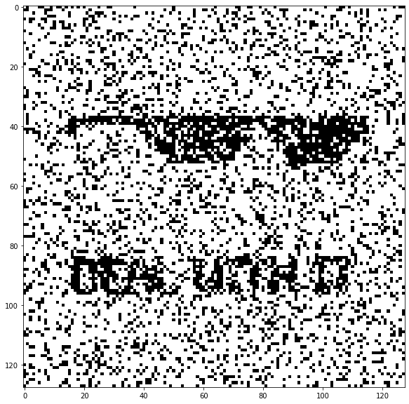

```python
plt.imshow(noisy_deal, cmap='Greys', interpolation='nearest')
plt.show()
```

Ahora podemos comenzar con eso y usar los pesos para actualizarlo. Actualizaremos las unidades de forma asincrónica (una a la vez).

Mientras actualizamos las unidades, hagamos un seguimiento de la **energía** en la red:

[figure not shown]

La actualización de las activaciones de las unidades hace que la red se mueva hacia un mínimo local en esa función. En términos más informales, la actualización de las unidades pone a la red en un estado más "relajado".

Matemáticas de matriz numpy eficientes para calcular la energía tomada de [aqui](https://codeaffectionate.blogspot.com/2013/05/fun-with-hopfield-and-numpy.html).

```python
def flow(pattern, weights, theta=0, steps = 50000):

    pattern_flat = pattern.flatten()

    if (type(theta) == float) or (type(theta) == int):
        thetas = np.zeros(len(pattern_flat)) + theta

    for step in range(steps):
        unit = np.random.randint(low=0, high=(len(pattern_flat)-1))
        unit_weights = weights[unit,:]
        net_input = np.dot(unit_weights,pattern_flat)
        pattern_flat[unit] = 1 if (net_input > thetas[unit]) else -1

        if (step % 10000) == 0:
            energy = -0.5*np.dot(np.dot(pattern_flat.T,weights),pattern_flat) + np.dot(thetas,pattern_flat)
            print("Energy at step {:05d} is now {}".format(step,energy))

    evolved_pattern = np.reshape(a=pattern_flat, newshape=(pattern.shape[0],pattern.shape[1]))

    return evolved_pattern
```

```python
steps = 50000
theta = 0

noisy_deal_evolved = flow(noisy_deal, deal_weights, theta = theta, steps = steps)
```

```
Energy at step 00000 is now -45631266.0
Energy at step 10000 is now -79901890.0
Energy at step 20000 is now -101922450.0
Energy at step 30000 is now -116761570.0
Energy at step 40000 is now -124432896.0
```

Como se esperaba, la energía disminuye a medida que se actualizan las activaciones de las unidades. Ahora traza el patrón 'evolucionado'.

[figure not shown]

```python
plt.imshow(noisy_deal_evolved, cmap='Greys', interpolation='nearest')
plt.show()
```

## Entrenando la red en un segundo patrón

Lo mejor de las redes Hopfield es que pueden codificar múltiples patrones (hasta un límite dependiendo del régimen de entrenamiento y el número de unidades). Así que intentemos otro maymay.

Tengo el siguiente meme de [aqui](https://68.media.tumblr.com/avatar_0f24a9a67d83_128.png), y luego ajustó sus niveles en la vista previa de Mac para que se tradujera muy bien en una imagen de 1 bit (blanco o negro).

```python
woah = imread('woah.png', mode="L")
woah = woah.astype(int)
woah[woah >= 1] = 1
woah[woah < 1] = -1
woah = -woah
```

```python
np.unique(woah)
```

```
array([-1,  1])
```

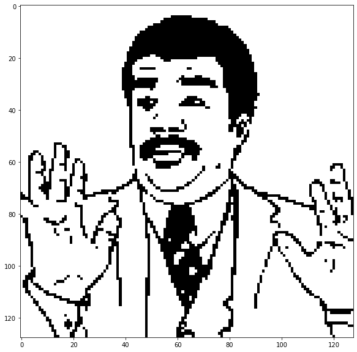

```python
plt.imshow(woah, cmap='Greys', interpolation='nearest')
plt.show()
```

Así que ahora hacemos algunos pesos para esta imagen ...

```python
flattened_woah = woah.flatten()

flatlen = len(flattened_woah)

woah_weights = np.outer(flattened_woah,flattened_woah) - np.identity(len(flattened_woah))
```

... y luego solo promedia aquellos con los pesos para la red 'lidiar con eso'. Esto lleva un tiempo sorprendentemente largo (10-15 segundos).

```python
average_weights = (woah_weights + deal_weights) / 2
```

Ahora, hagamos un ruidoso Neil deGrasse Tyson, y haga que la red intente recuperar el NGT limpio y prístino.

[figure not shown]

```python
noisy_woah = noisify(pattern=woah)

plt.imshow(noisy_woah, cmap='Greys', interpolation='nearest')
plt.show()
```

```
Energy at step 00000 is now -28765821.0
Energy at step 10000 is now -51436533.0
Energy at step 20000 is now -65367113.0
Energy at step 30000 is now -73687313.0
Energy at step 40000 is now -78738593.0
```

[figure not shown]

```python
recovered_woah = flow(noisy_woah, average_weights, theta = theta, steps = steps)

plt.imshow(recovered_woah, cmap='Greys', interpolation='nearest')
plt.show()
```

Ahora, verifiquemos que los pesos promedio también funcionen para la imagen 'lidiar con eso'.

```
Energy at step 00000 is now -28672913.0
Energy at step 10000 is now -50887029.0
Energy at step 20000 is now -64494945.0
Energy at step 30000 is now -74135093.0
Energy at step 40000 is now -79003753.0
```

[figure not shown]

```python
deal_recovered = flow(noisy_deal, average_weights, theta = theta, steps = steps)

plt.imshow(deal_recovered, cmap='Greys', interpolation='nearest')
plt.show()
```

Así que *ahora* podemos intentar algo como alimentarlo con un patrón que esté a medio camino entre los dos patrones: ¡con el tiempo debería conformarse con uno de ellos! ¿Quién tiene mayor fuerza de meme?

```python
deal_with_neil = (woah + deal) / 2
print(np.unique(deal_with_neil))
```

```
[-1.  0.  1.]
```

Podríamos forzar esos valores 0 a -1 o 1, pero eso sesga el patrón hacia deal y neil, respectivamente (al menos, las pruebas sugirieron esto; creo que porque Neil tiene más píxeles negros y Deal tiene más píxeles blancos). Por lo tanto, los dejaré. Probablemente *podría* resolver esto estableciendo aleatoriamente 0's a 1 o -1, pero no.

[figure not shown]

```python
plt.imshow(deal_with_neil, cmap='Greys', interpolation='nearest')
plt.show()
```

```
Energy at step 00000 is now -76762245.0
Energy at step 10000 is now -78519120.0
Energy at step 20000 is now -80885001.0
Energy at step 30000 is now -82439010.0
Energy at step 40000 is now -83348880.0
```

[figure not shown]

```python
recovered_deal_with_neil = flow(deal_with_neil, average_weights, theta = theta, steps = steps)

plt.imshow(recovered_deal_with_neil, cmap='Greys', interpolation='nearest')
plt.show()
```

*Suponiendo que las celdas / píxeles de 0 no hayan sido alterados*, si lo ejecutas varias veces, notarás que a veces se establece en Neil, ¡y a veces se establece en Deal!

## Patrones espurios

Las redes Hopfield también pueden establecerse en 'patrones espurios' (patrones en los que la red no fue entrenada). Para cada patrón almacenado `x`,`-x` es un patrón espurio. Pero también, cualquier combinación lineal de los patrones aprendidos puede ser un patrón espurio. Entonces, aprendamos un tercer patrón y luego veamos cómo la red se estabiliza en una combinación simple de los tres patrones.

[figure not shown]

```python
meme1 = imread('meme2.png', mode="L")
meme1 = meme1.astype(int)
meme1[meme1 >= 1] = 1
meme1[meme1 < 1] = -1

plt.imshow(meme1, cmap='Greys', interpolation='nearest')
plt.show()
```

```python
flattened_ = meme1.flatten()

flatlen = len(flattened_)

_weights = np.outer(flattened_,flattened_) - np.identity(len(flattened_))
```

```python
average_weights = (woah_weights + deal_weights + _weights) / 3
```

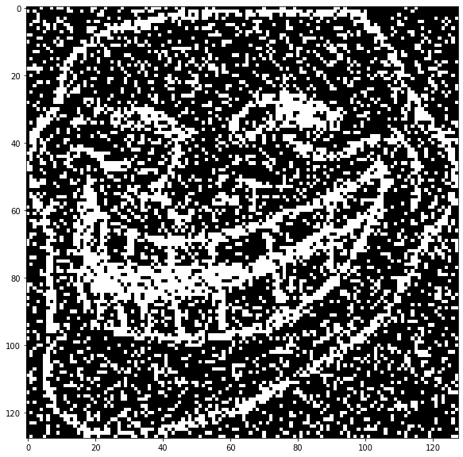

```python
noisy_butt = noisify(pattern=meme1)

plt.imshow(noisy_butt, cmap='Greys', interpolation='nearest')
plt.show()
```

```
Energy at step 00000 is now -20807424.66666665
Energy at step 10000 is now -36483035.99999999
Energy at step 20000 is now -47099465.333333254
Energy at step 30000 is now -53834059.333333164
Energy at step 40000 is now -57186547.333333105
```

[figure not shown]

```python
recovered_butt = flow(noisy_butt, average_weights, theta=theta, steps=steps)

plt.imshow(recovered_butt, cmap='Greys', interpolation='nearest')
plt.show()
```

```
Energy at step 00000 is now -21358550.000000007
Energy at step 10000 is now -37670659.333333544
Energy at step 20000 is now -48625443.33333326
Energy at step 30000 is now -54918741.99999971
Energy at step 40000 is now -58401867.33333295
```

[figure not shown]

```python
recovered_woah = flow(noisy_woah, average_weights, theta=theta, steps=steps)

plt.imshow(recovered_woah, cmap='Greys', interpolation='nearest')
plt.show()
```

Bien, ahora hagamos un patrón espurio. Cualquier combinación lineal servirá.

```python
spurious_meme = meme1 + deal + woah
np.unique(spurious_meme)
```

```
array([-3, -1,  1,  3])
```

```python
spurious_meme[spurious_meme > 0] = 1
spurious_meme[spurious_meme < 0] = -1
```

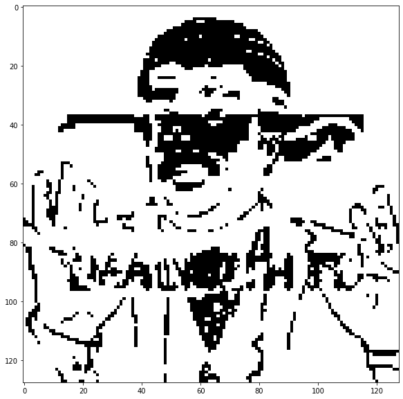

```python
plt.imshow(spurious_meme, cmap='Greys', interpolation='nearest')
plt.show()
```

Bastante ruidoso Solo Neal, y kiiiiinda the Deal with It, son visibles. Ahora haga una versión ruidosa de esa combinación.

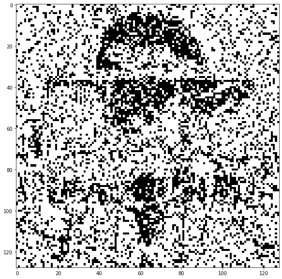

```python
noisy_spurious_meme = noisify(pattern=spurious_meme)

plt.imshow(noisy_spurious_meme, cmap='Greys', interpolation='nearest')
plt.show()
```

Bellamente ruidoso. Apenas puedo ver nada en él. Pero ahora, si comenzamos con eso y aplicamos los pesos, ¡debería recuperar el patrón espurio!

```
Energy at step 00000 is now -18133436.000000034
Energy at step 10000 is now -36670659.3333334
Energy at step 20000 is now -50277251.99999994
Energy at step 30000 is now -59879465.33333345
Energy at step 40000 is now -65554395.333333455
Energy at step 50000 is now -68469627.33333349
Energy at step 60000 is now -70112139.33333346
Energy at step 70000 is now -70729587.33333334
Energy at step 80000 is now -71112628.00000007
Energy at step 90000 is now -71337372.00000003
```

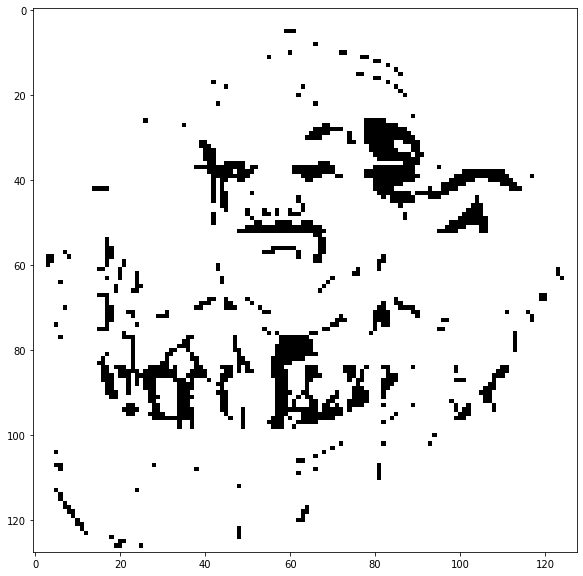

```python
steps = 100000

recovered_spurious_meme = flow(noisy_spurious_meme, average_weights, theta=theta, steps=steps)

plt.imshow(recovered_spurious_meme, cmap='Greys', interpolation='nearest')
plt.show()
```

## Animaciones

Hagamos algunas animaciones ingeniosas de las redes recuperando un patrón (aprendido o espurio) de una entrada. Hagamos que la entrada sea más o menos puro ruido, aumentando `numb_flipped`.

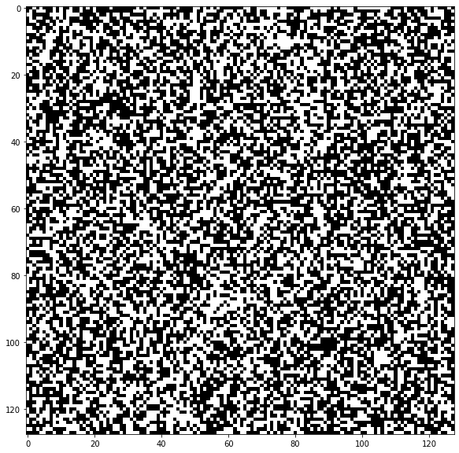

```python
noise = noisify(pattern=woah, numb_flipped=100)

plt.imshow(noise, cmap='Greys', interpolation='nearest')
plt.show()
```

Excelente. Eso seguro parece puro ruido.

```
Energy at step 00000 is now -485713.3333333327
Energy at step 10000 is now -16010372.000000004
Energy at step 20000 is now -33134291.333333462
Energy at step 30000 is now -45310624.66666677
Energy at step 40000 is now -53055173.99999983
```

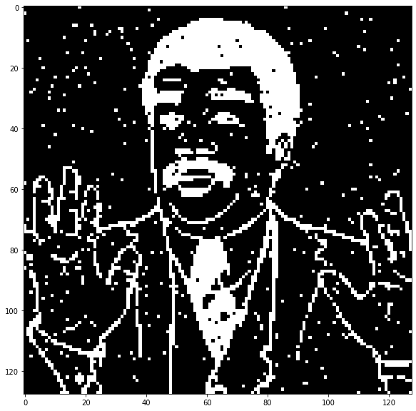

```python
steps = 50000

recovered_meme = flow(noise, average_weights, theta=theta, steps=steps)

plt.imshow(recovered_meme, cmap='Greys', interpolation='nearest')
plt.show()
```

Dado que el ruido es básicamente una imagen aleatoria, la red podría establecerse en cualquiera de los atractores (módulo *qué* atractivos son cada uno), por lo que la imagen de arriba variará de una ejecución a otra.

```python
steps = 50000
noisy_meme_flat = noise.flatten()
os.chdir('recovery_steps')

for step in range(steps):
    unit = np.random.randint(low=0, high=(len(noisy_meme_flat)-1))
    unit_weights = average_weights[unit,:]
    net_input = np.dot(unit_weights,noisy_meme_flat)

    noisy_meme_flat[unit] = 1 if (net_input > theta) else -1

    recovered_meme = np.reshape(a=noisy_meme_flat, newshape=(len(meme1),len(meme1)))
    #if not (step % 1000):
    #    imsave('recovered_meme{:05d}.jpg'.format(step), recovered_meme)
```

```python
filenames = [x for x in os.listdir() if x[-4:] == '.jpg']
images = []
for filename in filenames:
    images.append(imageio.imread(filename))
os.chdir("..")
imageio.mimsave('meme_movie.gif', images, duration=0.2)
```

[figure not shown]